# PositiveMetabolomics

Aroosha Raja

## Load Libraries

This section loads necessary libraries #Working directory: setwd(“/Users/araja2/Desktop/Metabolomics”)

```r
library(tidyverse)
library(dplyr)
library(FactoMineR)
library(factoextra)
library(imputeTS)
library(cluster)
```

```r
library(impute)
library(ggplot2)
library(mice)
library(mixOmics)
library(limma)
library(reshape2)
library(ggrepel)
library(ggplot2)
library(ggpubr)
library(readxl)
conflicted::conflicts_prefer(dplyr::filter)
```

```
## [conflicted] Will prefer dplyr::filter over any other package.
```

This section defines global color scheme which we used for plots within our analysis

```r
plot_colors <- c(
  "0µM ERAP1 inhibitor" = "#E69F00",
  "10µM ERAP1 inhibitor" = "#0072B2",
  "50µM ERAP1 inhibitor" = "#009E73",
  "KO" = "#999933",
  "Reference" = "red"
)

volcano_colors <- c(
  "Upregulated" = "#D32F2F",
  "Downregulated" = "#1976D2",
  "Not Significant" = "grey80"
)
boxplot_colors <- c(
  "0µM ERAP1 inhibitor" = "#E69F00",
  "10µM ERAP1 inhibitor" = "#0072B2",
  "50µM ERAP1 inhibitor" = "#009E73",
  "KO" = "red"
)
```

This section includes Data import and preprocessing including missing (NA) value imputation.

```r
data <- read_excel("P-24XXX_ArooshaNetherlands_HIMet_finalnew.xlsx", sheet = 1)
df <- as.data.frame(data)
df <- df %>% slice(-1:-8)
colnames(df) <- as.character(unlist(df[1, ]))
df <- df[-1, ]
sample_cols <- grep("id|PRCS|STRD|MTRX|CMTRX|WT|KO", names(df), value = TRUE)
filtered_cols <- sample_cols[grepl("^id$|^Btc", sample_cols)]
pca_data <- df[, filtered_cols[filtered_cols != "id"]]
pca_data <- as.data.frame(lapply(pca_data, function(x) as.numeric(as.character(x))))
```

[output not shown]

```r
imputed_data <- mice(pca_data, m = 1, method = 'rf', seed = 500)
imputed_numeric_data <- complete(imputed_data)

id_column <- df[, "id"]
complete_data <- cbind(id = id_column, imputed_numeric_data)

filtered_columns <- grepl("CMTRX|WT_DMSO|WT_10uM|WT_50uM|KO|^id$", colnames(complete_data))
filtered_data <- complete_data[, filtered_columns]

transposed_data <- as.data.frame(t(filtered_data[, -1]))
colnames(transposed_data) <- filtered_data$id

phenotype_labels <- gsub("^.*_(CMTRX|WT_DMSO|WT_10uM|WT_50uM|KO)_.*$", "\\1", colnames(filtered_data))
phenotype_labels <- phenotype_labels[phenotype_labels %in% c("CMTRX", "WT_DMSO", "WT_10uM", "WT_50uM", "KO")]
transposed_data$Phenotype <- phenotype_labels
transposed_data <- transposed_data[, c("Phenotype", setdiff(names(transposed_data), "Phenotype"))]
```

The following section includes the scaling of data using Variable Stability Scaling (VAST) to stabilise the variance across variables while preserving the metabolites having higher mean intensities.

```r
numeric_data <- transposed_data[, sapply(transposed_data, is.numeric)]
vast_scaling <- function(x) {
  variable_mean <- mean(x, na.rm = TRUE)
  variable_sd <- sd(x, na.rm = TRUE)
  ((x - variable_mean) / variable_sd) * (variable_mean / variable_sd)
}
vast_scaled_data <- as.data.frame(lapply(numeric_data, vast_scaling))
vast_scaled_data <- data.frame(Phenotype = transposed_data$Phenotype, vast_scaled_data)
```

Principle component Analysis:

```r
metabolite_data1 <- vast_scaled_data[, -1]
metabolite_data1 <- as.data.frame(lapply(metabolite_data1, as.numeric))
unique_labels <- make.unique(as.character(phenotype_labels))
rownames(metabolite_data1) <- unique_labels
pca_result <- prcomp(metabolite_data1, scale. = FALSE)
summary(pca_result)
```

```
## Importance of components:
##                            PC1      PC2      PC3      PC4      PC5      PC6
## Standard deviation     61.0574 32.98977 28.78339 22.67192 22.02578 21.62656
## Proportion of Variance  0.3341  0.09753  0.07424  0.04606  0.04347  0.04191
## Cumulative Proportion   0.3341  0.43161  0.50585  0.55191  0.59539  0.63730
##                             PC7      PC8      PC9     PC10     PC11     PC12
## Standard deviation     19.73741 18.44158 18.12455 16.79049 15.99165 15.56400
## Proportion of Variance  0.03491  0.03048  0.02944  0.02526  0.02292  0.02171
## Cumulative Proportion   0.67221  0.70269  0.73212  0.75739  0.78031  0.80201
##                            PC13     PC14     PC15     PC16     PC17     PC18
## Standard deviation     14.37023 14.11164 13.90044 13.40747 13.22740 12.83511
## Proportion of Variance  0.01851  0.01785  0.01732  0.01611  0.01568  0.01476
## Cumulative Proportion   0.82052  0.83836  0.85568  0.87179  0.88747  0.90223
##                            PC19     PC20    PC21     PC22     PC23     PC24
## Standard deviation     12.29228 12.10780 11.6200 11.30716 10.86048 10.67971
## Proportion of Variance  0.01354  0.01314  0.0121  0.01146  0.01057  0.01022
## Cumulative Proportion   0.91577  0.92891  0.9410  0.95246  0.96303  0.97326
##                           PC25     PC26    PC27      PC28
## Standard deviation     10.2965 10.06968 9.54075 3.398e-14
## Proportion of Variance  0.0095  0.00909 0.00816 0.000e+00
## Cumulative Proportion   0.9828  0.99184 1.00000 1.000e+00
```

```r
num_points <- nrow(pca_result$x)
cat("Number of metabolites represented in PCA plot:", num_points, "\n")
```

[output not shown]

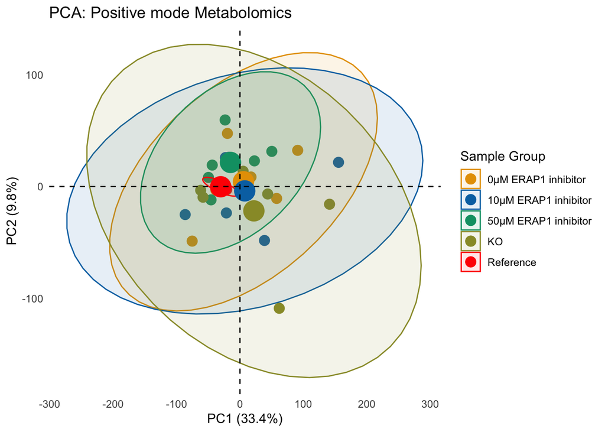

```r
sample_labels <- case_when(
  grepl("KO", rownames(metabolite_data1)) ~ "KO",
  grepl("CMTRX", rownames(metabolite_data1)) ~ "Reference",
  grepl("WT_DMSO", rownames(metabolite_data1)) ~ "0µM ERAP1 inhibitor",
  grepl("WT_10uM", rownames(metabolite_data1)) ~ "10µM ERAP1 inhibitor",
  grepl("WT_50uM", rownames(metabolite_data1)) ~ "50µM ERAP1 inhibitor",
  TRUE ~ "Other"
)
sample_labels <- factor(sample_labels, levels = names(plot_colors))
#####pca_plot <- fviz_pca_ind(pca_result,
#axes = c(1, 2),
#geom = c("point"),
#col.ind = sample_labels,
#palette = c("#E69F00", "#0072B2", "#009E73", "#999933", "red"),
#title = "PCA",
#pointsize = 4,
#legend.title = "Sample Group",
#addEllipses = TRUE)
####PCA plot#####
pca_plot <- fviz_pca_ind(pca_result,
                         axes = c(1, 2),
                         geom = "point",
                         col.ind = sample_labels,
                         palette = plot_colors,
                         title = "PCA: Positive mode Metabolomics",
                         pointsize = 4,
                         legend.title = "Sample Group",
                         addEllipses = TRUE) + theme_minimal() +
                         theme(panel.grid = element_blank()) +
                         scale_shape_manual(values = rep(16, length(unique(sample_labels)))) +
                         guides(col = guide_legend(override.aes = list(shape = 16, size = 4))) +
                         xlab("PC1 (33.4%)") +
                         ylab("PC2 (9.8%)")
pca_plot
```

```r
#ggsave("Positive_pca_plot.svg", plot = pca_plot, width = 8, height = 6, device = "svg")
```

[figure not shown]

```r
metabolite_data_matrix <- as.matrix(metabolite_data1)
rownames(metabolite_data_matrix) <- paste0(vast_scaled_data$Phenotype, "_", seq_len(nrow(vast_scaled_data)))

phenotype_labels <- factor(trimws(vast_scaled_data$Phenotype))
phenotype_labels <- droplevels(phenotype_labels[phenotype_labels != "CMTRX"])
keep_rows <- vast_scaled_data$Phenotype != "CMTRX"
metabolite_data_matrix <- metabolite_data_matrix[keep_rows, ]
rownames(metabolite_data_matrix) <- paste0(vast_scaled_data$Phenotype[keep_rows], "_", seq_len(sum(keep_rows)))

design <- model.matrix(~ 0 + phenotype_labels)
colnames(design) <- levels(phenotype_labels)
rownames(design) <- rownames(metabolite_data_matrix)

fit <- lmFit(t(metabolite_data_matrix), design)
contrast <- makeContrasts(KO - WT_DMSO, levels = design)
fit2 <- contrasts.fit(fit, contrast)
fit2 <- eBayes(fit2)
#FDR adjustment
p_adjusted <- p.adjust(fit2$p.value, method = "fdr")
fit2$p_adjusted <- p_adjusted
#head(fit2)
fit2_df <- data.frame(
  Metabolite = rownames(fit2$t),
  logFC = fit2$coefficients[, 1],
  t_stat = fit2$t[, 1],
  p_value = fit2$p.value[, 1],
  p_adjusted = fit2$p_adjusted,
  adj.p.value= fit2$F.p.value)
#View(fit2_df)

top_results <- topTable(fit2, number = 10)
#print(top_results)
#contrasts (WT_DMSO: 0µM ERAP1 inhibitor, WT_10 and WT_50: 10 and 50µM ERAP1 inhibitor, KO: ERAP1 knockout)
contrast_ko_wt <- makeContrasts(KO - WT_DMSO, levels = design)
contrast_50_wt <- makeContrasts(WT_50uM - WT_DMSO, levels = design)
contrast_10_wt <- makeContrasts(WT_10uM - WT_DMSO, levels = design)

#Fit model for KO vs WT_DMSO
fit_ko_wt <- contrasts.fit(fit, contrast_ko_wt)
fit_ko_wt <- eBayes(fit_ko_wt)
top_results_ko_wt <- topTable(fit_ko_wt, number = 10)
#print(top_results_ko_wt)
results_wt_ko <- topTable(fit_ko_wt, number = Inf, sort.by = "p")
ko_wt_sig_adj=results_wt_ko[results_wt_ko$adj.P.Val<=0.05, ]
ko_wt_sig_p=results_wt_ko[results_wt_ko$P.Value<=0.05, ]
sum(results_wt_ko$adj.P.Val <= 0.05)
```

```
## [1] 32
```

```r
sum(results_wt_ko$P.Value <= 0.05)
```

```
## [1] 311
```

```r
#Fit model for WT_50uM vs WT_DMSO
fit_50_wt <- contrasts.fit(fit, contrast_50_wt)
fit_50_wt <- eBayes(fit_50_wt)
top_results_50_wt <- topTable(fit_50_wt, number = 10)
#print(top_results_50_wt)
results_wt_50 <- topTable(fit_50_wt, number = Inf, sort.by = "p")
sum(results_wt_50$adj.P.Val <= 0.05)
```

```
## [1] 0
```

```r
sum(results_wt_50$P.Value <= 0.05)
```

```
## [1] 206
```

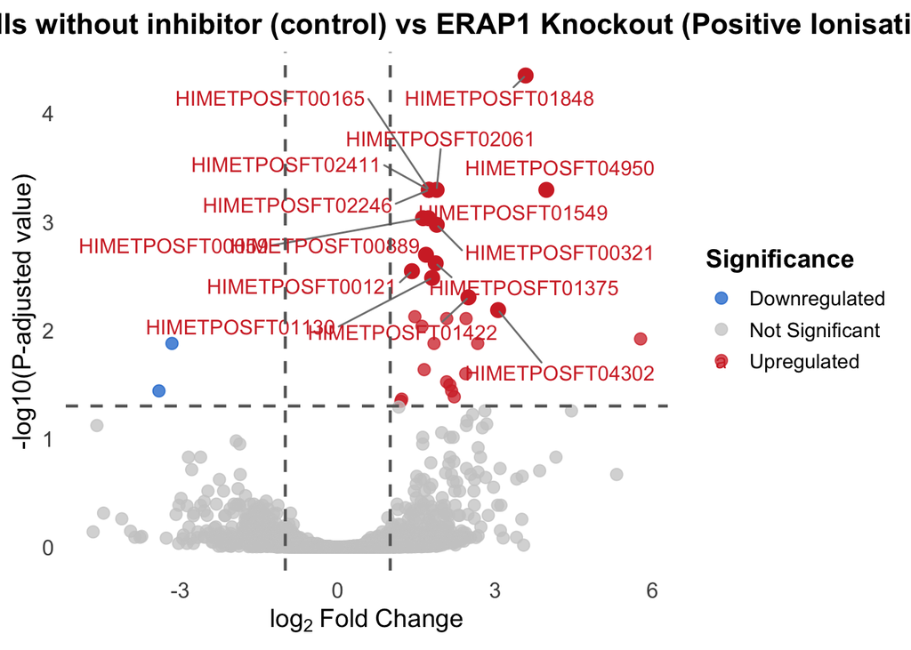

```r
wt_50_sig_p=results_wt_50[results_wt_50$adj.P.Val<=0.05, ]
results_wt50_wt <- topTable(fit_50_wt, number = Inf, sort.by = "p")

###Volcano plot###
results_wt_ko$Significance <- "Not Significant"
results_wt_ko$Significance[results_wt_ko$adj.P.Val < 0.05 & results_wt_ko$logFC > 0.5] <- "Upregulated"
results_wt_ko$Significance[results_wt_ko$adj.P.Val < 0.05 & results_wt_ko$logFC < -0.5] <- "Downregulated"
top_metabolites <- rownames(results_wt_ko)[1:15]
results_wt_ko$Label <- ifelse(rownames(results_wt_ko) %in% top_metabolites, rownames(results_wt_ko), "")
volcano_ko_wt <- ggplot(results_wt_ko, aes(x = logFC, y = -log10(adj.P.Val), color = Significance)) +
  geom_point(alpha = 0.75, size = 2.8) +
  geom_point(
    data = results_wt_ko[results_wt_ko$Label != "", ],
    aes(x = logFC, y = -log10(adj.P.Val)),
    color = volcano_colors["Upregulated"],
    size = 3.5
  ) +
  geom_text_repel(
    data = results_wt_ko[results_wt_ko$Label != "", ],
    aes(label = Label),
    size = 4,
    max.overlaps = 15,
    box.padding = 0.5,
    segment.color = "grey50"
  ) +
  scale_color_manual(values = volcano_colors) +
  geom_vline(xintercept = c(-1, 1), linetype = "dashed", color = "grey40", linewidth = 0.8) +
  geom_hline(yintercept = -log10(0.05), linetype = "dashed", color = "grey40", linewidth = 0.8) +
  labs(
    title = "ERAP1-component cells without inhibitor (control) vs ERAP1 Knockout (Positive Ionisation Mode)",
    x = expression(log[2]~Fold~Change),
    y = "-log10(P-adjusted value)",
    color = "Significance"
  ) +
  theme_minimal(base_size = 14) +
  theme(
    plot.title = element_text(size = 16, face = "bold", hjust = 0.5),
    axis.text = element_text(size = 12),
    legend.title = element_text(face = "bold"),
    legend.position = "right",
    panel.grid.major = element_blank(),
    panel.grid.minor = element_blank(),
    plot.background = element_rect(fill = "white", color = NA)
  )
volcano_ko_wt
```

```r
#ggsave("Positive_WTvsKO_plot.svg", plot = volcano_ko_wt, width = 7, height = 6, units = "in", device = "svg")
```

This section includes the Boxplot analysis using ANOVA for key metabolite features to compare between conditions under study

[figure not shown]

```r
selected_ids <- c(
  "HIMETPOSFT09948", "HIMETPOSFT08071", "HIMETPOSFT08805", "HIMETPOSFT10814",
  "HIMETPOSFT09547", "HIMETPOSFT06068", "HIMETPOSFT10197", "HIMETPOSFT06207",
  "HIMETPOSFT08949", "HIMETPOSFT10211", "HIMETPOSFT12121", "HIMETPOSFT12258",
  "HIMETPOSFT06097", "HIMETPOSFT06296", "HIMETPOSFT08263", "HIMETPOSFT04227"
)

metabolite_names <- c(
  "HIMETPOSFT09948" = "citrulline [M+H]+",
  "HIMETPOSFT08071" = "glutamine [M+H]+",
  "HIMETPOSFT08805" = "glutathione [M+H]+",
  "HIMETPOSFT10814" = "glutathione disulfide [M+H]+",
  "HIMETPOSFT09547" = "histidine [M+H]+",
  "HIMETPOSFT06068" = "isoleucine/leucine [M+H]+",
  "HIMETPOSFT10197" = "lysine [M+H]+",
  "HIMETPOSFT06207" = "phenylalanine [M+H]+",
  "HIMETPOSFT08949" = "phosphocholine [M+H]+",
  "HIMETPOSFT10211" = "S-adenosyl-L-methionine [M]+",
  "HIMETPOSFT12121" = "spermidine [M+H]+",
  "HIMETPOSFT12258" = "spermine [M+H]+",
  "HIMETPOSFT06097" = "sphingosine 1-phosphate [M+H]+",
  "HIMETPOSFT06296" = "tryptophan [M-NH2+H]+",
  "HIMETPOSFT08263" = "tyrosine [M+H]+",
  "HIMETPOSFT04227" = "choline [M]+"
)
filtered_data1 <- complete_data %>% filter(id %in% selected_ids)
#head(filtered_data1)
long_df <- filtered_data1 %>%
  pivot_longer(cols = -id, names_to = "Sample", values_to = "Concentration") %>%
  mutate(
    Condition = case_when(
      str_detect(Sample, "WT_DMSO") ~ "0µM ERAP1 inhibitor",
      str_detect(Sample, "WT_10uM") ~ "10µM ERAP1 inhibitor",
      str_detect(Sample, "WT_50uM") ~ "50µM ERAP1 inhibitor",
      str_detect(Sample, "KO") ~ "KO",
      TRUE ~ NA_character_
    ),
    Concentration = as.numeric(Concentration),
    Concentration = log10(Concentration + 1),
    FacetLabel = metabolite_names[id]
  ) %>%
  filter(!is.na(Condition) & !is.na(FacetLabel))

g <- ggplot(long_df, aes(x = Condition, y = Concentration, color = Condition)) +
  geom_boxplot(outlier.shape = NA, size = 1.5, color = "black", fill = NA) +
  geom_jitter(width = 0.2, alpha = 0.8, size = 3, shape = 16, show.legend = TRUE) +
  stat_compare_means(
    method = "anova",
    label = "p.format",
    label.y.npc = 0.95,
    size = 4,
    fontface = "bold",
    color = "black"
  ) +
  scale_color_manual(values = boxplot_colors) +
  facet_wrap(~ FacetLabel, scales = "free_y", nrow = 4, ncol = 5) +
  labs(
    x = NULL,
    y = expression(log[10]*"(µMol + 1)"),
    color = "Condition"
  ) +
  guides(color = guide_legend(override.aes = list(size = 5))) +
  theme_pubr(base_size = 18) +
  theme(
    legend.position = "bottom",
    legend.text = element_text(size = 12, face = "bold"),
    legend.title = element_text(size = 13, face = "bold"),
    legend.key.size = unit(1.5, "lines"),
    strip.text = element_text(face = "bold", color = "black", size = 12),
    strip.background = element_blank(),
    axis.text.x = element_text(angle = 90, hjust = 1, size = 10, face = "bold"),
    axis.text.y = element_text(size = 10, face = "bold"),
    axis.title.y = element_text(size = 14, face = "bold"),
    axis.title.x = element_text(margin = margin(t = 10), face = "bold"),
    panel.spacing = unit(1.5, "lines"),
    plot.margin = margin(12, 12, 12, 12),
    panel.border = element_rect(color = "black", linewidth = 1.2, fill = NA),
    axis.line = element_line(color = "black", linewidth = 1.2)
  )
g
```

```r
#ggsave("Positive_ERAP1metabolites_boxplot.svg", g, width = 15, height = 15, dpi = 600, units = "in")
```